# Lab7-part1

Isabel Sassoon

2022-10-27

# Logistic Regression Lab

This markdown document walks through the infection data example introduced in the lecture.

## Loading the required libraries

If i get the rlang problem, uninstall the package and run this line

```r
#install.packages("rlang")
```

```r
library(ggplot2)
```

Recall from the lecture we have data about the presence and absence of a parasite infection….

We may want to use this data to answer the following question: *Do gender, age or weight have an effect on the likelihood of having an infection?*

When reading in the data it is best to make sure that the target variable is indeed being treated as a factor.

Reading in the dataset infection.csv

```r
infection<-read.csv("infection.csv",stringsAsFactors = T)
head(infection)
```

```
##   infected age weight    sex
## 1   absent   2      1 female
## 2   absent   9     13 female
## 3  present  15      2 female
## 4   absent  15     16 female
## 5   absent  18      2 female
## 6   absent  20      9 female
```

Lets see how many infection cases are in this data:

```r
table(infection$infected)
```

```
##
##  absent present
##      64      17
```

We can confirm that infected has two values `absent/present`, it is binary so it is suitable to model it using logistic regression.

But before we do it, lets explore the rest of the data. We have three explanatory variables: two numeric and one categorical.

```r
summary(infection)
```

```
##     infected       age             weight          sex
##  absent :64   Min.   :  1.00   Min.   : 1.00   female:28
##  present:17   1st Qu.: 26.00   1st Qu.: 9.00   male  :53
##               Median : 87.00   Median :13.00
##               Mean   : 83.65   Mean   :11.49
##               3rd Qu.:130.00   3rd Qu.:16.00
##               Max.   :206.00   Max.   :18.00
```

### Graphical exploration of the data

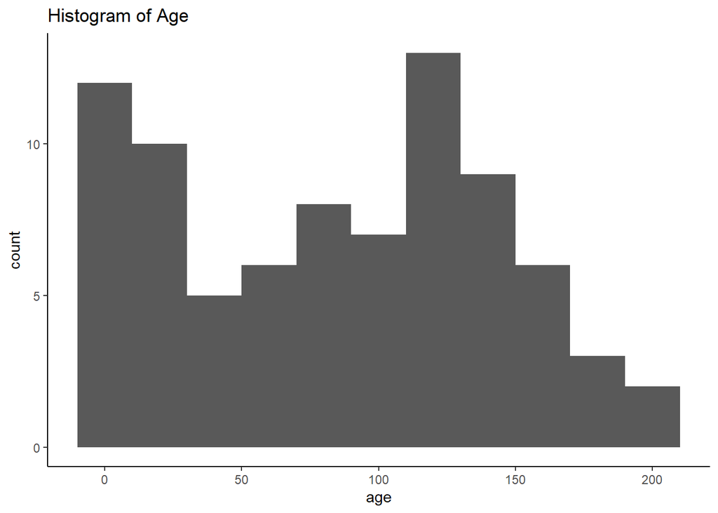

```r
ggplot(infection, aes(x=age)) + geom_histogram(binwidth = 20) + ggtitle("Histogram of Age")+ theme_classic()
```

This looks like it has a suspicious bulk of cases where age is < 25. Note that for logistic regression we dont need to be concerned with assumptions such as normal distributions in the data.

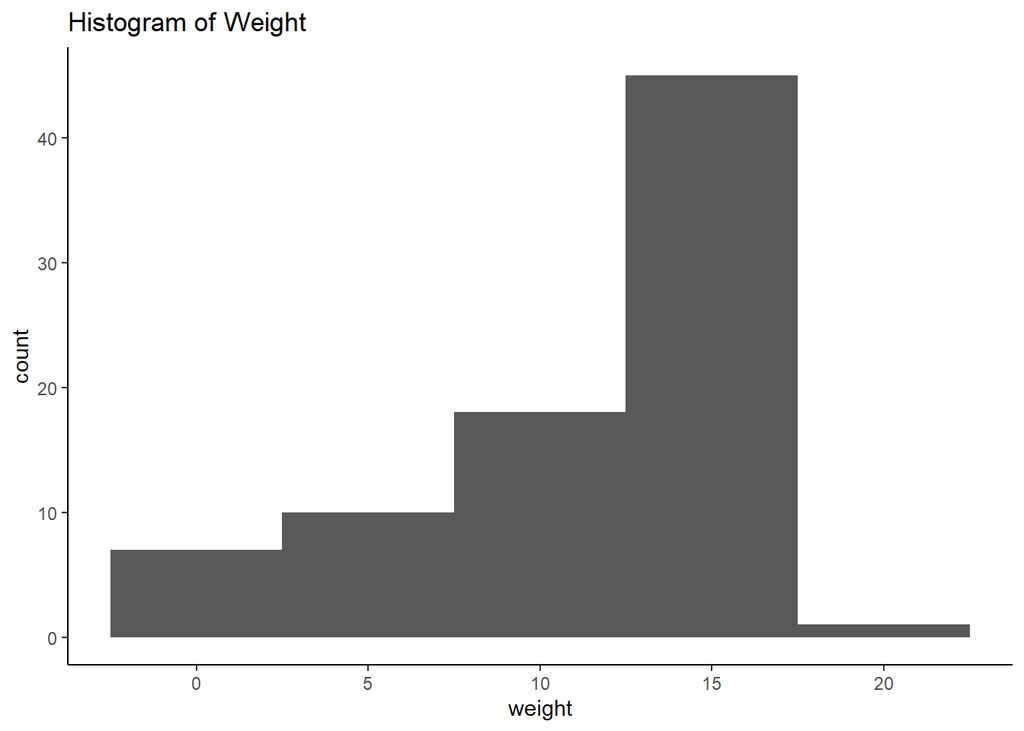

```r
ggplot(infection, aes(x=weight)) + geom_histogram(binwidth = 5) + ggtitle("Histogram of Weight")+ theme_classic()
```

This is a skewed to the left distributions. But as noted before for logistic regression we dont need to be concerned with assumptions such as normal distributions in the data.

Lets check how these two numerical explanatory variables correlate to each other

```r
cor.test(infection$age, infection$weight)
```

```
##
##  Pearson's product-moment correlation
##
## data:  infection$age and infection$weight
## t = 0.51485, df = 79, p-value = 0.6081
## alternative hypothesis: true correlation is not equal to 0
## 95 percent confidence interval:
##  -0.1625743  0.2727336
## sample estimates:
##        cor
## 0.05782789
```

The p-value of this test is large and supports what we saw in the scatter plot - there is no correlation between age and weight in this data.

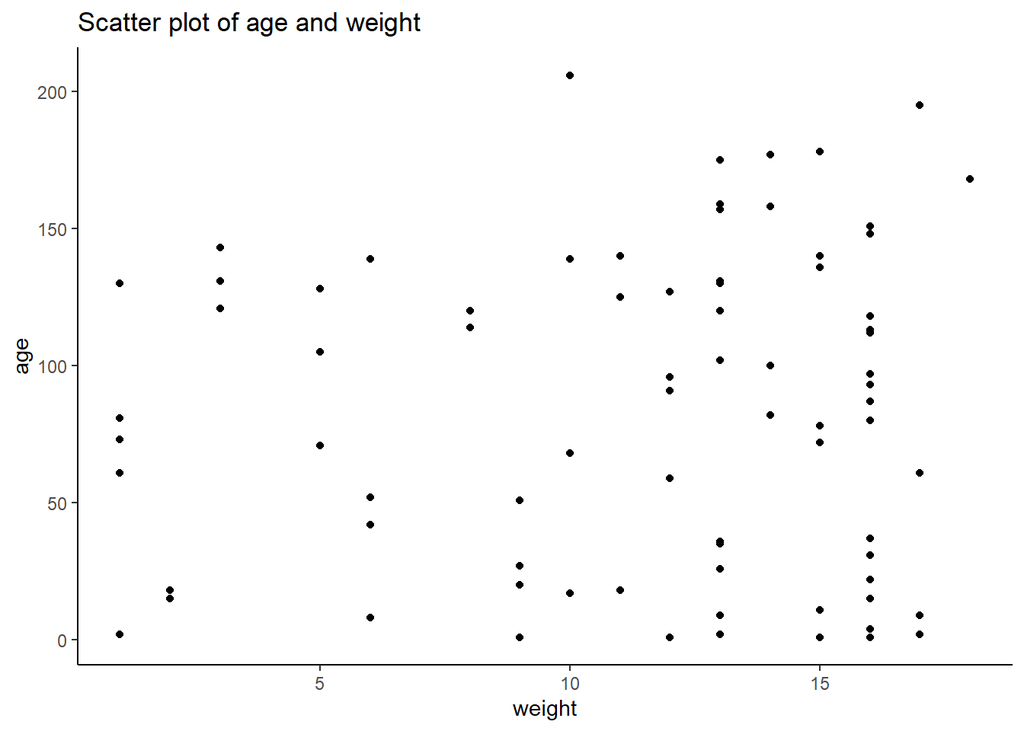

```r
ggplot(infection, aes(x=weight, y=age)) + geom_point() + ggtitle("Scatter plot of age and weight") + theme_classic()
```

The scatter plot confirms that there is no correlation. (What we would be looking out for is very high correlation - ref week 6 multicollinearity)

Exploring the relationship between the target variable and the two numerical explanatory variables:

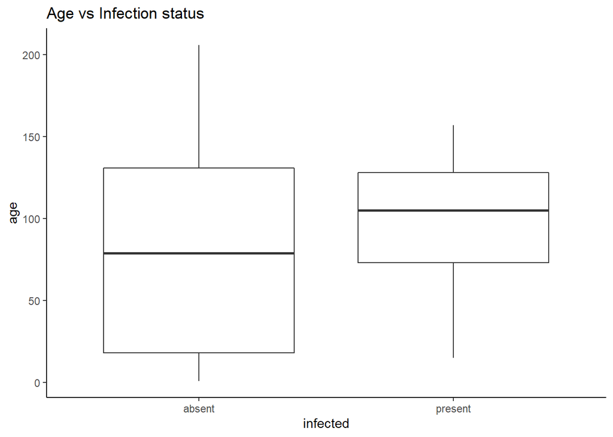

```r
ggplot(infection, aes(x=infected, y=age))+ geom_boxplot() + theme_classic()+ ggtitle("Age vs Infection status")
```

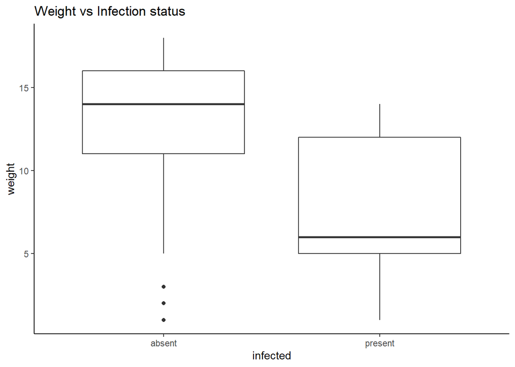

```r
ggplot(infection, aes(x=infected, y=weight))+ geom_boxplot() + theme_classic() + ggtitle("Weight vs Infection status")
```

It seems that both age and weight’s median are different when infections are present or absent.

Following from the inspection of the data using numerical summaries and graphs there are no issues to report with the data (suspicious, missing or outliers) and looking at the distributions there are no issues to prevent all the explanatory variables from being considered in the maximal model.

## Logistic regression

In order to explain the relationship between our binary *target variable* `(infected)` and the explanatory variables we are using logistic regression:

Lets start with this maximal model without interactions just to focus on the process and interpreting the outputs.

```r
infection.lr<-glm(infection$infected~infection$age+ infection$weight+infection$sex, family=binomial)
summary(infection.lr)
```

```
##
## Call:
## glm(formula = infection$infected ~ infection$age + infection$weight +
##     infection$sex, family = binomial)
##
## Deviance Residuals:
##     Min       1Q   Median       3Q      Max
## -1.9481  -0.5284  -0.3120  -0.1437   2.2525
##
## Coefficients:
##                    Estimate Std. Error z value Pr(>|z|)
## (Intercept)        0.609369   0.803288   0.759 0.448096
## infection$age      0.012653   0.006772   1.868 0.061701 .
## infection$weight  -0.227912   0.068599  -3.322 0.000893 ***
## infection$sexmale -1.543444   0.685681  -2.251 0.024388 *
## ---
## Signif. codes:  0 '***' 0.001 '**' 0.01 '*' 0.05 '.' 0.1 ' ' 1
##
## (Dispersion parameter for binomial family taken to be 1)
##
##     Null deviance: 83.234  on 80  degrees of freedom
## Residual deviance: 59.859  on 77  degrees of freedom
## AIC: 67.859
##
## Number of Fisher Scoring iterations: 5
```

We can see that this model has significant coefficients for weight and gender.

And we can interpret the model as follows:

For Gender = Male:
$$log(\frac{p}{1-p})=0.6+0.013 \times \text{age}-
0.23 \times \text{weight} -1.543 \times 1$$

For Gender = Female:
$$log(\frac{p}{1-p})=0.6+0.013 \times \text{age}-
0.23 \times \text{weight} -1.543 \times 0$$

*The diagnostic plots are not applicable to logistic regression as the assumptions that we were checking for in linear models are not relevant.*

If you were to look at plot(model) the only potential useful insight would be from the last plot (no 4) to identify the outliers.

*Remember*: This was just an indicative model to explain the output. Now lets start with a maximal model (including interactions) and the use `step` function to simplify.

We can start looking at a starting point for a model with interactions:

## Logistic regression model with interactions***

```r
infection.max.lr<-glm(infection$infected~infection$age*infection$weight*infection$sex, family=binomial)
summary(infection.max.lr)
```

```
##
## Call:
## glm(formula = infection$infected ~ infection$age * infection$weight *
##     infection$sex, family = binomial)
##
## Deviance Residuals:
##     Min       1Q   Median       3Q      Max
## -2.1767  -0.5359  -0.2494  -0.1691   2.3149
##
## Coefficients:
##                                                   Estimate Std. Error z value
## (Intercept)                                      -0.109124   1.375388  -0.079
## infection$age                                     0.024128   0.020874   1.156
## infection$weight                                 -0.074156   0.147678  -0.502
## infection$sexmale                                -5.969109   4.278066  -1.395
## infection$age:infection$weight                   -0.001977   0.002006  -0.985
## infection$age:infection$sexmale                   0.038086   0.041325   0.922
## infection$weight:infection$sexmale                0.213830   0.343265   0.623
## infection$age:infection$weight:infection$sexmale -0.001651   0.003419  -0.483
##                                                  Pr(>|z|)
## (Intercept)                                         0.937
## infection$age                                       0.248
## infection$weight                                    0.616
## infection$sexmale                                   0.163
## infection$age:infection$weight                      0.325
## infection$age:infection$sexmale                     0.357
## infection$weight:infection$sexmale                  0.533
## infection$age:infection$weight:infection$sexmale    0.629
##
## (Dispersion parameter for binomial family taken to be 1)
##
##     Null deviance: 83.234  on 80  degrees of freedom
## Residual deviance: 55.706  on 73  degrees of freedom
## AIC: 71.706
##
## Number of Fisher Scoring iterations: 6
```

This is the maximal model and none of the coefficients are appearing significant. Lets do some model selection to see if this can be improved.

## step function model

```r
step(infection.max.lr)
```

```
## Start:  AIC=71.71
## infection$infected ~ infection$age * infection$weight * infection$sex
##
##                                                Df Deviance    AIC
## - infection$age:infection$weight:infection$sex  1   55.943 69.943
## <none>                                              55.706 71.706
##
## Step:  AIC=69.94
## infection$infected ~ infection$age + infection$weight + infection$sex +
##     infection$age:infection$weight + infection$age:infection$sex +
##     infection$weight:infection$sex
##
##                                  Df Deviance    AIC
## - infection$weight:infection$sex  1   56.122 68.122
## - infection$age:infection$sex     1   57.828 69.828
## <none>                                55.943 69.943
## - infection$age:infection$weight  1   58.674 70.674
##
## Step:  AIC=68.12
## infection$infected ~ infection$age + infection$weight + infection$sex +
##     infection$age:infection$weight + infection$age:infection$sex
##
##                                  Df Deviance    AIC
## <none>                                56.122 68.122
## - infection$age:infection$sex     1   58.142 68.142
## - infection$age:infection$weight  1   58.899 68.899
```

```
##
## Call:  glm(formula = infection$infected ~ infection$age + infection$weight +
##     infection$sex + infection$age:infection$weight + infection$age:infection$sex,
##     family = binomial)
##
## Coefficients:
##                     (Intercept)                    infection$age
##                       -0.391566                         0.025764
##                infection$weight                infection$sexmale
##                       -0.036494                        -3.743771
##  infection$age:infection$weight  infection$age:infection$sexmale
##                       -0.002221                         0.020464
##
## Degrees of Freedom: 80 Total (i.e. Null);  75 Residual
## Null Deviance:       83.23
## Residual Deviance: 56.12     AIC: 68.12
```

Lets look at the resulting model in more detail:

```r
infection.mam.glm<-glm(formula = infection$infected ~ infection$age + infection$weight +
    infection$sex + infection$age:infection$weight + infection$age:infection$sex,
    family = binomial)
summary(infection.mam.glm)
```

```
##
## Call:
## glm(formula = infection$infected ~ infection$age + infection$weight +
##     infection$sex + infection$age:infection$weight + infection$age:infection$sex,
##     family = binomial)
##
## Deviance Residuals:
##     Min       1Q   Median       3Q      Max
## -2.1599  -0.5643  -0.2230  -0.1359   2.3490
##
## Coefficients:
##                                  Estimate Std. Error z value Pr(>|z|)
## (Intercept)                     -0.391566   1.265230  -0.309   0.7570
## infection$age                    0.025764   0.014921   1.727   0.0842 .
## infection$weight                -0.036494   0.128993  -0.283   0.7772
## infection$sexmale               -3.743771   1.791962  -2.089   0.0367 *
## infection$age:infection$weight  -0.002221   0.001365  -1.627   0.1038
## infection$age:infection$sexmale  0.020464   0.015232   1.343   0.1791
## ---
## Signif. codes:  0 '***' 0.001 '**' 0.01 '*' 0.05 '.' 0.1 ' ' 1
##
## (Dispersion parameter for binomial family taken to be 1)
##
##     Null deviance: 83.234  on 80  degrees of freedom
## Residual deviance: 56.122  on 75  degrees of freedom
## AIC: 68.122
##
## Number of Fisher Scoring iterations: 6
```

We can see that Gender is significant but the others are not.

## Odd ratios and Odds

To calculate the odd ratios, we use the following steps:

```r
#using the model :infection.lr
#extract the coefficients of the model using coef()
#exponentiate the coefficients
exp(coef(infection.lr))
```

```
##       (Intercept)     infection$age  infection$weight infection$sexmale
##         1.8392700         1.0127333         0.7961940         0.2136441
```

The odds ratios can tell us what effect a change in the dependent variable has on the odds of being infected, in this model and data.

Interpreting this: For a one unit increase in age, the odds of infection increase by a factor of 1.01 - in other words they increase by a small amount. The odds of infection for gender=male are 0.21 - in other words they decrease by a factor 0.21.

We can summarise that age increases infection likelihood marginally. Weight and gender = male decrease the likelihood.

We can also use the model to predict the probability of being infected using:

```r
#predict the probability of infection from the model
infection$pinfection<-predict(infection.lr, type="response")
head(infection)
```

```
##   infected age weight    sex pinfection
## 1   absent   2      1 female 0.60031127
## 2   absent   9     13 female 0.09624894
## 3  present  15      2 female 0.58500119
## 4   absent  15     16 female 0.05481403
## 5   absent  18      2 female 0.59418590
## 6   absent  20      9 female 0.23347650
```